# Project: Investigate a Dataset :- (TMDP-Movies)

# The primary goal of the project is to go through the dataset and the general data analysis process using numpy, pandas and matplotlib. This contain four parts:

- Introduction
- Data Wrangling
- Exploratory Data Analysis
- Conclusions

## Introduction

### Dataset Description

This data set contains information about 10,000 movies collected from The Movie Database (TMDb), including user ratings and revenue.I would like to find other intresting patterns in the dataset.

### Question(s) for Analysis

1- What is the top (10) & low (10) movies bassed on the rating?

2- which year that has the most release movies and least?

3- The top and low profit movie?

4- What is the average popularity by generes?

5- Is there is a relation between this columns (vote average & popularity) , (release year & revenue & profit)?

```python
# Use this cell to set up import statements for all of the packages that you
#   plan to use.
import numpy as np
import pandas as pd
import matplotlib.pyplot as plt
import seaborn as sns
%matplotlib inline
```

## Data Wrangling

After Observing the dataset and the questions related to this dataset for the analysis we will be keeping only relevent data and deleting the unused data.

### General Properties

```python
# Read the database csv file.
df= pd.read_csv('tmdb-movies.csv')
# show a punch of the original data using head() function.
df.head()
```

|  | id | imdb_id | popularity | budget | revenue | original_title | cast | homepage | director | tagline | ... | overview | runtime | genres | production_companies | release_date | vote_count | vote_average | release_year | budget_adj | revenue_adj |
| --- | --- | --- | --- | --- | --- | --- | --- | --- | --- | --- | --- | --- | --- | --- | --- | --- | --- | --- | --- | --- | --- |
| 0 | 135397 | tt0369610 | 32.985763 | 150000000 | 1513528810 | Jurassic World | Chris Pratt\|Bryce Dallas Howard\|Irrfan Khan\|Vi... | http://www.jurassicworld.com/ | Colin Trevorrow | The park is open. | ... | Twenty-two years after the events of Jurassic ... | 124 | Action\|Adventure\|Science Fiction\|Thriller | Universal Studios\|Amblin Entertainment\|Legenda... | 6/9/15 | 5562 | 6.5 | 2015 | 1.379999e+08 | 1.392446e+09 |
| 1 | 76341 | tt1392190 | 28.419936 | 150000000 | 378436354 | Mad Max: Fury Road | Tom Hardy\|Charlize Theron\|Hugh Keays-Byrne\|Nic... | http://www.madmaxmovie.com/ | George Miller | What a Lovely Day. | ... | An apocalyptic story set in the furthest reach... | 120 | Action\|Adventure\|Science Fiction\|Thriller | Village Roadshow Pictures\|Kennedy Miller Produ... | 5/13/15 | 6185 | 7.1 | 2015 | 1.379999e+08 | 3.481613e+08 |
| 2 | 262500 | tt2908446 | 13.112507 | 110000000 | 295238201 | Insurgent | Shailene Woodley\|Theo James\|Kate Winslet\|Ansel... | http://www.thedivergentseries.movie/#insurgent | Robert Schwentke | One Choice Can Destroy You | ... | Beatrice Prior must confront her inner demons ... | 119 | Adventure\|Science Fiction\|Thriller | Summit Entertainment\|Mandeville Films\|Red Wago... | 3/18/15 | 2480 | 6.3 | 2015 | 1.012000e+08 | 2.716190e+08 |
| 3 | 140607 | tt2488496 | 11.173104 | 200000000 | 2068178225 | Star Wars: The Force Awakens | Harrison Ford\|Mark Hamill\|Carrie Fisher\|Adam D... | http://www.starwars.com/films/star-wars-episod... | J.J. Abrams | Every generation has a story. | ... | Thirty years after defeating the Galactic Empi... | 136 | Action\|Adventure\|Science Fiction\|Fantasy | Lucasfilm\|Truenorth Productions\|Bad Robot | 12/15/15 | 5292 | 7.5 | 2015 | 1.839999e+08 | 1.902723e+09 |
| 4 | 168259 | tt2820852 | 9.335014 | 190000000 | 1506249360 | Furious 7 | Vin Diesel\|Paul Walker\|Jason Statham\|Michelle ... | http://www.furious7.com/ | James Wan | Vengeance Hits Home | ... | Deckard Shaw seeks revenge against Dominic Tor... | 137 | Action\|Crime\|Thriller | Universal Pictures\|Original Film\|Media Rights ... | 4/1/15 | 2947 | 7.3 | 2015 | 1.747999e+08 | 1.385749e+09 |

5 rows × 21 columns

```python
# show the original data columns details.
df.info()
```

```
<class 'pandas.core.frame.DataFrame'>
RangeIndex: 10866 entries, 0 to 10865
Data columns (total 21 columns):
 #   Column                Non-Null Count  Dtype
---  ------                --------------  -----
 0   id                    10866 non-null  int64
 1   imdb_id               10856 non-null  object
 2   popularity            10866 non-null  float64
 3   budget                10866 non-null  int64
 4   revenue               10866 non-null  int64
 5   original_title        10866 non-null  object
 6   cast                  10790 non-null  object
 7   homepage              2936 non-null   object
 8   director              10822 non-null  object
 9   tagline               8042 non-null   object
 10  keywords              9373 non-null   object
 11  overview              10862 non-null  object
 12  runtime               10866 non-null  int64
 13  genres                10843 non-null  object
 14  production_companies  9836 non-null   object
 15  release_date          10866 non-null  object
 16  vote_count            10866 non-null  int64
 17  vote_average          10866 non-null  float64
 18  release_year          10866 non-null  int64
 19  budget_adj            10866 non-null  float64
 20  revenue_adj           10866 non-null  float64
dtypes: float64(4), int64(6), object(11)
memory usage: 1.7+ MB
```

```python
# Get the columns and raws count
df.shape
```

```
(10866, 21)
```

```python
df.describe()
```

|  | id | popularity | budget | revenue | runtime | vote_count | vote_average | release_year | budget_adj | revenue_adj |
| --- | --- | --- | --- | --- | --- | --- | --- | --- | --- | --- |
| count | 10866.000000 | 10866.000000 | 1.086600e+04 | 1.086600e+04 | 10866.000000 | 10866.000000 | 10866.000000 | 10866.000000 | 1.086600e+04 | 1.086600e+04 |
| mean | 66064.177434 | 0.646441 | 1.462570e+07 | 3.982332e+07 | 102.070863 | 217.389748 | 5.974922 | 2001.322658 | 1.755104e+07 | 5.136436e+07 |
| std | 92130.136561 | 1.000185 | 3.091321e+07 | 1.170035e+08 | 31.381405 | 575.619058 | 0.935142 | 12.812941 | 3.430616e+07 | 1.446325e+08 |
| min | 5.000000 | 0.000065 | 0.000000e+00 | 0.000000e+00 | 0.000000 | 10.000000 | 1.500000 | 1960.000000 | 0.000000e+00 | 0.000000e+00 |
| 25% | 10596.250000 | 0.207583 | 0.000000e+00 | 0.000000e+00 | 90.000000 | 17.000000 | 5.400000 | 1995.000000 | 0.000000e+00 | 0.000000e+00 |
| 50% | 20669.000000 | 0.383856 | 0.000000e+00 | 0.000000e+00 | 99.000000 | 38.000000 | 6.000000 | 2006.000000 | 0.000000e+00 | 0.000000e+00 |
| 75% | 75610.000000 | 0.713817 | 1.500000e+07 | 2.400000e+07 | 111.000000 | 145.750000 | 6.600000 | 2011.000000 | 2.085325e+07 | 3.369710e+07 |
| max | 417859.000000 | 32.985763 | 4.250000e+08 | 2.781506e+09 | 900.000000 | 9767.000000 | 9.200000 | 2015.000000 | 4.250000e+08 | 2.827124e+09 |

```python
# Get the null values and it's columns
df.isnull().sum()
```

```
id                         0
imdb_id                   10
popularity                 0
budget                     0
revenue                    0
original_title             0
cast                      76
homepage                7930
director                  44
tagline                 2824
keywords                1493
overview                   4
runtime                    0
genres                    23
production_companies    1030
release_date               0
vote_count                 0
vote_average               0
release_year               0
budget_adj                 0
revenue_adj                0
dtype: int64
```

### Data Cleaning

1- Remove duplicated raws

2- Fill missing data with apropiate values

3- Add profit column which equal revenue - budget

```python
# After discussing the structure of the data and any problems that need to be
#   cleaned, perform those cleaning steps in the second part of this section.
# Drop some unused columns in my ananlysis
df.drop(['imdb_id','keywords','overview','homepage','tagline','release_date','budget_adj','revenue_adj'],inplace = True,axis=1)
df.shape
```

```
(10866, 13)
```

```python
df.head()
```

|  | id | popularity | budget | revenue | original_title | cast | director | runtime | genres | production_companies | vote_count | vote_average | release_year |
| --- | --- | --- | --- | --- | --- | --- | --- | --- | --- | --- | --- | --- | --- |
| 0 | 135397 | 32.985763 | 150000000 | 1513528810 | Jurassic World | Chris Pratt\|Bryce Dallas Howard\|Irrfan Khan\|Vi... | Colin Trevorrow | 124 | Action\|Adventure\|Science Fiction\|Thriller | Universal Studios\|Amblin Entertainment\|Legenda... | 5562 | 6.5 | 2015 |
| 1 | 76341 | 28.419936 | 150000000 | 378436354 | Mad Max: Fury Road | Tom Hardy\|Charlize Theron\|Hugh Keays-Byrne\|Nic... | George Miller | 120 | Action\|Adventure\|Science Fiction\|Thriller | Village Roadshow Pictures\|Kennedy Miller Produ... | 6185 | 7.1 | 2015 |
| 2 | 262500 | 13.112507 | 110000000 | 295238201 | Insurgent | Shailene Woodley\|Theo James\|Kate Winslet\|Ansel... | Robert Schwentke | 119 | Adventure\|Science Fiction\|Thriller | Summit Entertainment\|Mandeville Films\|Red Wago... | 2480 | 6.3 | 2015 |
| 3 | 140607 | 11.173104 | 200000000 | 2068178225 | Star Wars: The Force Awakens | Harrison Ford\|Mark Hamill\|Carrie Fisher\|Adam D... | J.J. Abrams | 136 | Action\|Adventure\|Science Fiction\|Fantasy | Lucasfilm\|Truenorth Productions\|Bad Robot | 5292 | 7.5 | 2015 |
| 4 | 168259 | 9.335014 | 190000000 | 1506249360 | Furious 7 | Vin Diesel\|Paul Walker\|Jason Statham\|Michelle ... | James Wan | 137 | Action\|Crime\|Thriller | Universal Pictures\|Original Film\|Media Rights ... | 2947 | 7.3 | 2015 |

```python
df.isnull().sum()
```

```
id                         0
popularity                 0
budget                     0
revenue                    0
original_title             0
cast                      76
director                  44
runtime                    0
genres                    23
production_companies    1030
vote_count                 0
vote_average               0
release_year               0
dtype: int64
```

```python
# Fill null values with unknown string
df.fillna('unknown', inplace=True)
df.isnull().sum()
```

```
id                      0
popularity              0
budget                  0
revenue                 0
original_title          0
cast                    0
director                0
runtime                 0
genres                  0
production_companies    0
vote_count              0
vote_average            0
release_year            0
dtype: int64
```

```python
# Find the columns with 0 value
df.isin([0]).any()
```

```
id                      False
popularity              False
budget                   True
revenue                  True
original_title          False
cast                    False
director                False
runtime                  True
genres                  False
production_companies    False
vote_count              False
vote_average            False
release_year            False
dtype: bool
```

```python
df.revenue.isin([0]).value_counts()
```

```
True     6016
False    4850
Name: revenue, dtype: int64
```

```python
df.budget.isin([0]).value_counts()
```

```
True     5696
False    5170
Name: budget, dtype: int64
```

```python
df.runtime.isin([0]).value_counts()
```

```
False    10835
True        31
Name: runtime, dtype: int64
```

```python
df.isin([0]).any()
```

```
id                      False
popularity              False
budget                   True
revenue                  True
original_title          False
cast                    False
director                False
runtime                  True
genres                  False
production_companies    False
vote_count              False
vote_average            False
release_year            False
dtype: bool
```

```python
# Get the sum of duplicated raws
df.duplicated().sum()
```

```
1
```

```python
# Drop duplicated raws
df.drop_duplicates(inplace=True)
df.duplicated().sum()
```

```
0
```

```python
df['profit']=df['revenue'] - df['budget']
df.head()
```

|  | id | popularity | budget | revenue | original_title | cast | director | runtime | genres | production_companies | vote_count | vote_average | release_year | profit |
| --- | --- | --- | --- | --- | --- | --- | --- | --- | --- | --- | --- | --- | --- | --- |
| 0 | 135397 | 32.985763 | 150000000 | 1513528810 | Jurassic World | Chris Pratt\|Bryce Dallas Howard\|Irrfan Khan\|Vi... | Colin Trevorrow | 124 | Action\|Adventure\|Science Fiction\|Thriller | Universal Studios\|Amblin Entertainment\|Legenda... | 5562 | 6.5 | 2015 | 1363528810 |
| 1 | 76341 | 28.419936 | 150000000 | 378436354 | Mad Max: Fury Road | Tom Hardy\|Charlize Theron\|Hugh Keays-Byrne\|Nic... | George Miller | 120 | Action\|Adventure\|Science Fiction\|Thriller | Village Roadshow Pictures\|Kennedy Miller Produ... | 6185 | 7.1 | 2015 | 228436354 |
| 2 | 262500 | 13.112507 | 110000000 | 295238201 | Insurgent | Shailene Woodley\|Theo James\|Kate Winslet\|Ansel... | Robert Schwentke | 119 | Adventure\|Science Fiction\|Thriller | Summit Entertainment\|Mandeville Films\|Red Wago... | 2480 | 6.3 | 2015 | 185238201 |
| 3 | 140607 | 11.173104 | 200000000 | 2068178225 | Star Wars: The Force Awakens | Harrison Ford\|Mark Hamill\|Carrie Fisher\|Adam D... | J.J. Abrams | 136 | Action\|Adventure\|Science Fiction\|Fantasy | Lucasfilm\|Truenorth Productions\|Bad Robot | 5292 | 7.5 | 2015 | 1868178225 |
| 4 | 168259 | 9.335014 | 190000000 | 1506249360 | Furious 7 | Vin Diesel\|Paul Walker\|Jason Statham\|Michelle ... | James Wan | 137 | Action\|Crime\|Thriller | Universal Pictures\|Original Film\|Media Rights ... | 2947 | 7.3 | 2015 | 1316249360 |

## Exploratory Data Analysis

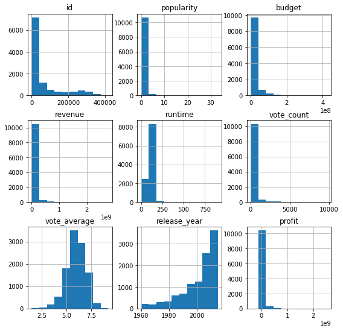

```python
# DataSet histograms
df.hist(figsize=(9,9));
```

```
It's obvious that the budget histogram is skewed to the right
```

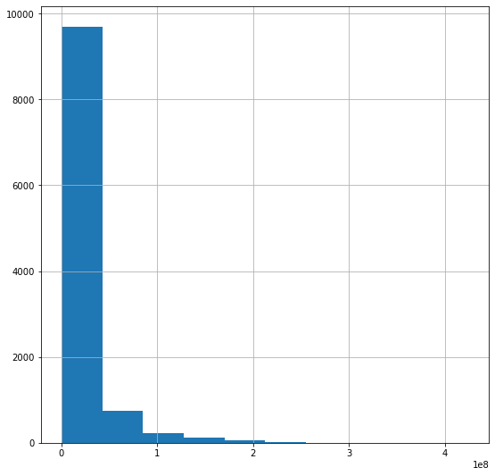

```python
df.budget.hist(figsize=(9,9));
print("It's obvious that the budget histogram is skewed to the right")
```

```
It's obvious that the release year histogram is skewed to the left
```

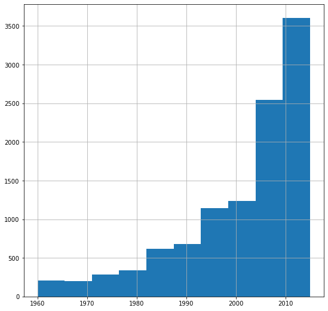

```python
df.release_year.hist(figsize=(9,9));
print("It's obvious that the release year histogram is skewed to the left")
```

### Research Question 1:- What is the top (10) & low (10) movies bassed on the rating?

```python
# Use this, and more code cells, to explore your data. Don't forget to add
#   Markdown cells to document your observations and findings.
# Q1:- What is the top(10) rating & low(10) rating movies?
top_rate = df.sort_values('vote_average',ascending = False)
top_rate.head(10)
```

|  | id | popularity | budget | revenue | original_title | cast | director | runtime | genres | production_companies | vote_count | vote_average | release_year | profit |
| --- | --- | --- | --- | --- | --- | --- | --- | --- | --- | --- | --- | --- | --- | --- |
| 3894 | 125336 | 0.006925 | 0 | 0 | The Story of Film: An Odyssey | Mark Cousins\|Jean-Michel Frodon\|Cari Beauchamp... | Mark Cousins | 900 | Documentary | unknown | 14 | 9.2 | 2011 | 0 |
| 538 | 224972 | 0.114264 | 0 | 0 | The Mask You Live In | unknown | Jennifer Siebel Newsom | 88 | Documentary | unknown | 11 | 8.9 | 2015 | 0 |
| 1200 | 374430 | 0.129531 | 0 | 0 | Black Mirror: White Christmas | Jon Hamm\|Rafe Spall\|Oona Chaplin\|Natalia Tena\|... | Carl Tibbetts | 74 | Drama\|Horror\|Mystery\|Science Fiction\|Thriller | unknown | 41 | 8.8 | 2014 | 0 |
| 2269 | 51299 | 0.222293 | 0 | 0 | Life Cycles | unknown | Derek Frankowski | 47 | Documentary | unknown | 27 | 8.8 | 2010 | 0 |
| 6911 | 24970 | 0.212010 | 0 | 0 | Pink Floyd: Pulse | David Gilmour\|Nick Mason\|Richard Wright\|Sam Br... | David Mallet | 145 | Music | SMV Enterprises\|Columbia Music Video\|EMI | 23 | 8.7 | 2006 | 0 |
| 2401 | 45644 | 0.067753 | 0 | 0 | Opeth: In Live Concert At The Royal Albert Hall | Mikael Ã…kerfeldt\|Martin "Axe" Axenrot\|Martin ... | unknown | 163 | Music | unknown | 10 | 8.6 | 2010 | 0 |
| 3690 | 68450 | 0.321341 | 0 | 0 | The Art of Flight | Travis Rice\|Nicolas Muller\|Mark Landvik\|Jake B... | Curt Morgan | 80 | Adventure\|Documentary | Red Bull Media House\|Brain Farm Digital Cinema | 60 | 8.5 | 2011 | 0 |
| 8411 | 25093 | 0.302908 | 0 | 0 | Queen - Rock Montreal | Freddie Mercury\|Roger Taylor\|John Deacon\|Brian... | Saul Swimmer | 138 | Music | Edel records GmbH | 14 | 8.5 | 1981 | 0 |
| 8221 | 55676 | 0.194889 | 0 | 0 | A Personal Journey with Martin Scorsese Throug... | Martin Scorsese\|Brian De Palma\|Gregory Peck\|Fr... | Martin Scorsese\|Michael Henry Wilson | 225 | Documentary | Miramax Films\|British Film Institute (BFI) | 11 | 8.5 | 1995 | 0 |
| 8839 | 16275 | 0.157001 | 0 | 0 | Dave Chappelle: Killin' Them Softly | Dave Chappelle | Stan Lathan | 57 | Comedy | unknown | 17 | 8.5 | 2000 | 0 |

```python
low_rate = df.sort_values('vote_average',ascending = False)
low_rate.tail(10)
```

|  | id | popularity | budget | revenue | original_title | cast | director | runtime | genres | production_companies | vote_count | vote_average | release_year | profit |
| --- | --- | --- | --- | --- | --- | --- | --- | --- | --- | --- | --- | --- | --- | --- |
| 7235 | 10838 | 0.209701 | 0 | 0 | Dracula 3000 | Casper Van Dien\|Erika Eleniak\|Coolio\|Grant Swa... | Darrell James Roodt | 86 | Horror\|Science Fiction | Film Afrika Worldwide\|ApolloProMedia GmbH & Co... | 12 | 2.3 | 2004 | 0 |
| 4910 | 86101 | 0.041297 | 0 | 0 | The Sleeper | Brittany Belland\|Riana Ballo\|Jessica Cameron\|J... | Justin Russell | 90 | Horror\|Comedy\|Thriller | Gamma Knife Films | 10 | 2.2 | 2012 | 0 |
| 4859 | 116977 | 0.111351 | 65000000 | 73706 | Foodfight! | Charlie Sheen\|Wayne Brady\|Hilary Duff\|Eva Long... | Lawrence Kasanoff | 87 | Animation\|Action\|Comedy\|Family | Threshold Entertainment\|Lions Gate Family Ente... | 12 | 2.2 | 2012 | -64926294 |
| 6077 | 203351 | 0.002648 | 0 | 0 | Atlantic Rim | Graham Greene\|David Chokachi\|Jackie Moore\|Nico... | Jared Cohn | 85 | Action\|Science Fiction | The Asylum\|Tiki Terrors | 21 | 2.2 | 2013 | 0 |
| 3822 | 83896 | 0.159707 | 0 | 0 | Sand Sharks | Corin Nemec\|Brooke Hogan\|Vanessa Evigan\|Eric S... | Mark Atkins | 87 | Comedy\|Horror\|Science Fiction | Rogue State\|Remember Dreaming Productions\|Litt... | 17 | 2.1 | 2011 | 0 |
| 7220 | 31117 | 0.157959 | 0 | 9109322 | Superbabies: Baby Geniuses 2 | Jon Voight\|Scott Baio\|Vanessa Angel\|Skyler Sha... | Bob Clark | 88 | Family\|Comedy | Crystal Sky Worldwide\|Triumph Films | 11 | 2.1 | 2004 | 9109322 |
| 2373 | 40016 | 0.150035 | 0 | 0 | Birdemic: Shock and Terror | Alan Bagh\|Whitney Moore\|Janae Caster\|Colton Os... | James Nguyen | 95 | Horror\|Science Fiction | unknown | 30 | 2.1 | 2010 | 0 |
| 4882 | 120846 | 0.079281 | 0 | 0 | Jurassic Shark | Emanuelle Carriere\|Christine Emes\|Celine Filio... | Brett Kelly | 75 | Action\|Horror\|Science Fiction | Dudez Productions | 13 | 2.0 | 2012 | 0 |
| 7772 | 25055 | 0.121120 | 0 | 0 | Transmorphers | Matthew Wolf\|Amy Weber\|Shaley Scott\|Eliza Swen... | Leigh Scott | 86 | Action\|Adventure\|Science Fiction | Asylum, The | 10 | 1.5 | 2007 | 0 |
| 10865 | 22293 | 0.035919 | 19000 | 0 | Manos: The Hands of Fate | Harold P. Warren\|Tom Neyman\|John Reynolds\|Dian... | Harold P. Warren | 74 | Horror | Norm-Iris | 15 | 1.5 | 1966 | -19000 |

### Research Question 2:- which year that has the most release movies and least?

```
The most year of releasing movies is: 2014 with 700 movie in this year
```

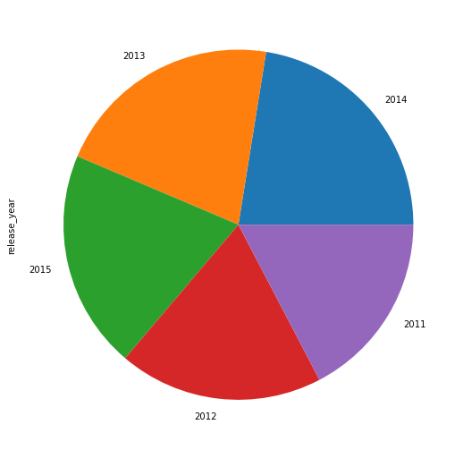

```python
# Continue to explore the data to address your additional research
#   questions. Add more headers as needed if you have more questions to
#   investigate.
# .nlargest to get largest values
most_release = df.groupby(['release_year'])['release_year'].count()
most_release.nlargest(n=5).plot(kind="pie", figsize=(9,9));
print('The most year of releasing movies is: 2014 with 700 movie in this year')
#most_release.plot(kind="pie", figsize=(9,9))
```

```
The least year of releasing movies are: 1961 and 1969. 31 movie for each year
```

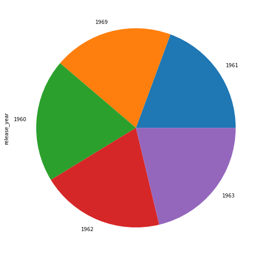

```python
least_release = df.groupby(['release_year'])['release_year'].count()
least_release.nsmallest(n=5).plot(kind="pie", figsize=(9,9));
print('The least year of releasing movies are: 1961 and 1969. 31 movie for each year')
```

```python
top_profit = df.sort_values('profit',ascending = False)
top_profit.head(1)

#print('The top profit movie is:{}\n The lowest profit movie is:{}'.format(top_profit,lowest_profit));
```

|  | id | popularity | budget | revenue | original_title | cast | director | runtime | genres | production_companies | vote_count | vote_average | release_year | profit |
| --- | --- | --- | --- | --- | --- | --- | --- | --- | --- | --- | --- | --- | --- | --- |
| 1386 | 19995 | 9.432768 | 237000000 | 2781505847 | Avatar | Sam Worthington\|Zoe Saldana\|Sigourney Weaver\|S... | James Cameron | 162 | Action\|Adventure\|Fantasy\|Science Fiction | Ingenious Film Partners\|Twentieth Century Fox ... | 8458 | 7.1 | 2009 | 2544505847 |

```python
lowest_profit = df.sort_values('profit',ascending = False)
#lowest_profit.tail(1)
#print('The top profit movie is:{}\n The lowest profit movie is:{}'.format(top_profit,lowest_profit));
```

### Research Question 4:- what is the average popularity by generes?

```python
# Split genres string, at |, explode the list to rows
genres_df = df.assign(genres=df['genres'].str.split('|')).explode('genres')
genres_df.head(10)
```

|  | id | popularity | budget | revenue | original_title | cast | director | runtime | genres | production_companies | vote_count | vote_average | release_year | profit |
| --- | --- | --- | --- | --- | --- | --- | --- | --- | --- | --- | --- | --- | --- | --- |
| 0 | 135397 | 32.985763 | 150000000 | 1513528810 | Jurassic World | Chris Pratt\|Bryce Dallas Howard\|Irrfan Khan\|Vi... | Colin Trevorrow | 124 | Action | Universal Studios\|Amblin Entertainment\|Legenda... | 5562 | 6.5 | 2015 | 1363528810 |
| 0 | 135397 | 32.985763 | 150000000 | 1513528810 | Jurassic World | Chris Pratt\|Bryce Dallas Howard\|Irrfan Khan\|Vi... | Colin Trevorrow | 124 | Adventure | Universal Studios\|Amblin Entertainment\|Legenda... | 5562 | 6.5 | 2015 | 1363528810 |
| 0 | 135397 | 32.985763 | 150000000 | 1513528810 | Jurassic World | Chris Pratt\|Bryce Dallas Howard\|Irrfan Khan\|Vi... | Colin Trevorrow | 124 | Science Fiction | Universal Studios\|Amblin Entertainment\|Legenda... | 5562 | 6.5 | 2015 | 1363528810 |
| 0 | 135397 | 32.985763 | 150000000 | 1513528810 | Jurassic World | Chris Pratt\|Bryce Dallas Howard\|Irrfan Khan\|Vi... | Colin Trevorrow | 124 | Thriller | Universal Studios\|Amblin Entertainment\|Legenda... | 5562 | 6.5 | 2015 | 1363528810 |
| 1 | 76341 | 28.419936 | 150000000 | 378436354 | Mad Max: Fury Road | Tom Hardy\|Charlize Theron\|Hugh Keays-Byrne\|Nic... | George Miller | 120 | Action | Village Roadshow Pictures\|Kennedy Miller Produ... | 6185 | 7.1 | 2015 | 228436354 |
| 1 | 76341 | 28.419936 | 150000000 | 378436354 | Mad Max: Fury Road | Tom Hardy\|Charlize Theron\|Hugh Keays-Byrne\|Nic... | George Miller | 120 | Adventure | Village Roadshow Pictures\|Kennedy Miller Produ... | 6185 | 7.1 | 2015 | 228436354 |
| 1 | 76341 | 28.419936 | 150000000 | 378436354 | Mad Max: Fury Road | Tom Hardy\|Charlize Theron\|Hugh Keays-Byrne\|Nic... | George Miller | 120 | Science Fiction | Village Roadshow Pictures\|Kennedy Miller Produ... | 6185 | 7.1 | 2015 | 228436354 |
| 1 | 76341 | 28.419936 | 150000000 | 378436354 | Mad Max: Fury Road | Tom Hardy\|Charlize Theron\|Hugh Keays-Byrne\|Nic... | George Miller | 120 | Thriller | Village Roadshow Pictures\|Kennedy Miller Produ... | 6185 | 7.1 | 2015 | 228436354 |
| 2 | 262500 | 13.112507 | 110000000 | 295238201 | Insurgent | Shailene Woodley\|Theo James\|Kate Winslet\|Ansel... | Robert Schwentke | 119 | Adventure | Summit Entertainment\|Mandeville Films\|Red Wago... | 2480 | 6.3 | 2015 | 185238201 |
| 2 | 262500 | 13.112507 | 110000000 | 295238201 | Insurgent | Shailene Woodley\|Theo James\|Kate Winslet\|Ansel... | Robert Schwentke | 119 | Science Fiction | Summit Entertainment\|Mandeville Films\|Red Wago... | 2480 | 6.3 | 2015 | 185238201 |

```python
# Group exploded dataframe by genres, get average popularity
genres_df.groupby('genres').popularity.mean()
```

```
genres
Action             0.926274
Adventure          1.154259
Animation          0.852182
Comedy             0.592607
Crime              0.744930
Documentary        0.181432
Drama              0.591495
Family             0.786668
Fantasy            0.992840
Foreign            0.191496
History            0.575936
Horror             0.465357
Music              0.487321
Mystery            0.690012
Romance            0.592082
Science Fiction    1.001548
TV Movie           0.270896
Thriller           0.741563
War                0.727683
Western            0.590615
unknown            0.167966
Name: popularity, dtype: float64
```

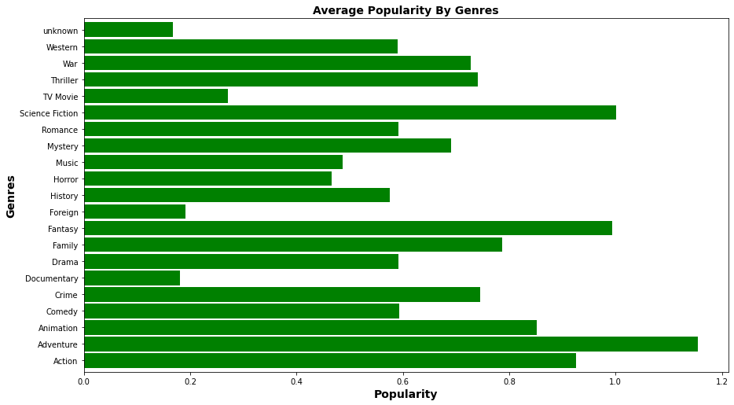

```python
# Grouby genres, get average popularity (or any of the continuous variables) and plot
genres_df.groupby('genres').popularity.mean().plot.barh(color=['g'],width=0.9,figsize=[14.70, 8.27],rot=0)
# Titles/Labels
plt.title("Average popularity by genres".title(), fontsize = 14, weight = "bold");
plt.xlabel("Popularity".title(), fontsize = 14, weight = "bold");
plt.ylabel("Genres".title(), fontsize = 14, weight = "bold");
#addTitlesLabels('popularity','genres','Average popularity by genres')
```

### Research Question 5:- Is there is a relation between this columns (vote average & popularity) , (release year & revenue & profit)

```python
def FillPlot(df,xVar,yVar,PlotKind):


    # Plot the values
    df.plot(x=xVar,y=yVar,kind=PlotKind,figsize=(14,8))

    # Replace the (_) with a white space to fill the title & labels
    xVar = xVar.replace("_"," ")
    yVar = yVar.replace("_"," ")
    # Add the plot title and format it
    plt.title(f'Relationship between {xVar} and {yVar}'.title(), fontsize = 14, weight = "bold")
    # Add the xLabel and format it
    plt.xlabel(xVar.title(), fontsize = 14, weight = "bold")
    # Add the yLabel and format it
    plt.ylabel(yVar.title(), fontsize = 14, weight = "bold")
```

```
It seems that the relation is littly positively relationship
```

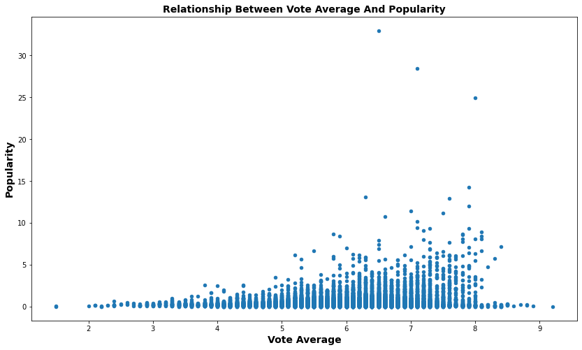

```python
#df.plot(x='vote_average',y='popularity',kind = 'scatter');
FillPlot(df,'vote_average','popularity','scatter');
print('It seems that the relation is littly positively relationship')
```

```
It seems that the relation is positively relationship between the revenue and release year
```

[figure not shown]

```python
#df.plot(x='release_year',y='revenue',kind = 'line');
FillPlot(df,'release_year','revenue','line');
print('It seems that the relation is positively relationship between the revenue and release year')
```

```
It seems that the relation is positively relationship between release year and profit
```

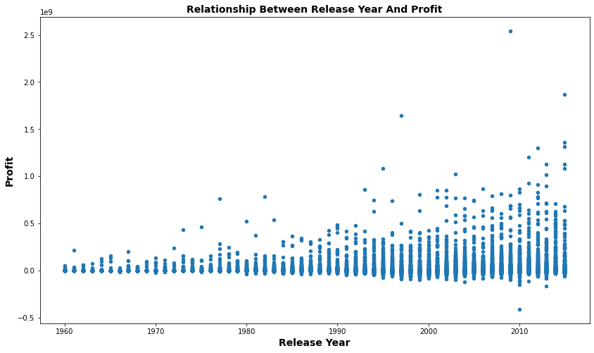

```python
#df.plot(x='release_year',y='profit',kind='scatter');
FillPlot(df,'release_year','profit','scatter');
print('It seems that the relation is positively relationship between release year and profit')
```

```
It seems that the relation is positively relationship between profit and revenue
```

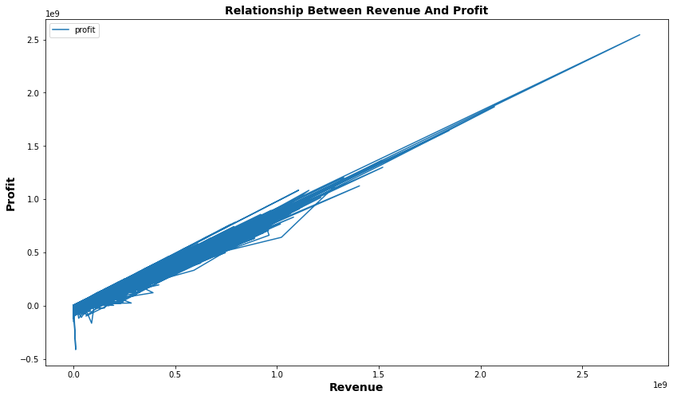

```python
FillPlot(df,'revenue','profit','line');
print('It seems that the relation is positively relationship between profit and revenue')
```

## Conclusions

1- You can see the top(10) movies based on rating above also the lowest(10)

2- a) 2014 is the year with most release movies: 700

b) 1961 and 1969 are the lowest years of releasing movies: 31

3- a) The top profit movie is: avater with net profit = 2544505847

4- The most popular genres is adventure

5- The relation between the columns are positively relationships.

### Limitations

The TMDB data set has alot of null values which could make the analysis isn't so accurate